# Homework 1

Gulsah Akcakir - IE582 - Fall 2018

18 Ekim 2018

We were given 2 different datasets to perform tasks of this homework. One of them presents the information of the matches played in Premier League from August 2010 till now. Other one, namely odd_details, includes all odd information of different bets of multiple bookmakers. Firstly, the datasets are examined and prepared to be used in following steps(See Appendix A).

#*Task 1* This task is to understand if bookmakers are good enough in setting their odds for over/under(ou) bet and only totalhandicap=2.5 cases are examined:

```r
odds_ou=odd_details[betType=='ou' & totalhandicap=='2.5']
```

To determine if bookmakers are good at deciding over/under 2.5 odds, some scatter plots of implied “over” probability average in a bin versus the fraction of games finished over for the corresponding bin will be given. Bins are created with a 0.1 increment.

```
##  [1] 0.0 0.1 0.2 0.3 0.4 0.5 0.6 0.7 0.8 0.9 1.0
```

Necessary info from two datasets are merged and an example of the final table belonging a specific bookmaker can be seen below:

```
##     Year odd_cut_over empirical_over probabilistic_over   N
##  1: 2011    (0.5,0.6]      0.5925926          0.5361605 135
##  2: 2011    (0.4,0.5]      0.4662162          0.4686306 148
##  3: 2011    (0.6,0.7]      0.7500000          0.6270976  12
##  4: 2011    (0.3,0.4]      0.3333333          0.3918841   3
##  5: 2012    (0.5,0.6]      0.5512195          0.5466676 205
##  6: 2012    (0.4,0.5]      0.4850746          0.4632765 134
##  7: 2012    (0.6,0.7]      0.6571429          0.6262416  35
##  8: 2012    (0.3,0.4]      0.0000000          0.3849910   3
##  9: 2013    (0.5,0.6]      0.5489130          0.5447091 184
## 10: 2013    (0.6,0.7]      0.6250000          0.6327545  48
## 11: 2013    (0.4,0.5]      0.4960630          0.4621801 127
## 12: 2013    (0.3,0.4]      0.1250000          0.3860280   8
## 13: 2014    (0.5,0.6]      0.5570470          0.5450407 149
## 14: 2014    (0.4,0.5]      0.4640523          0.4605890 153
```

[output cut: 19 more lines]

For simplification, 6 bookmakers are selected and the scatter plots are presented(See Appendix B):

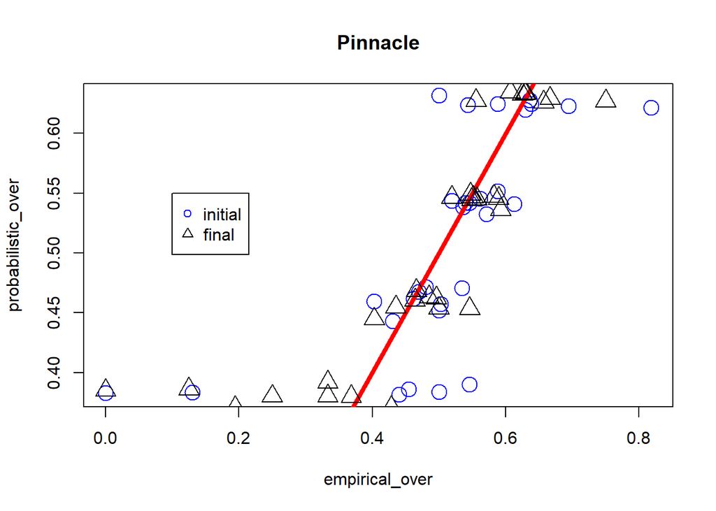

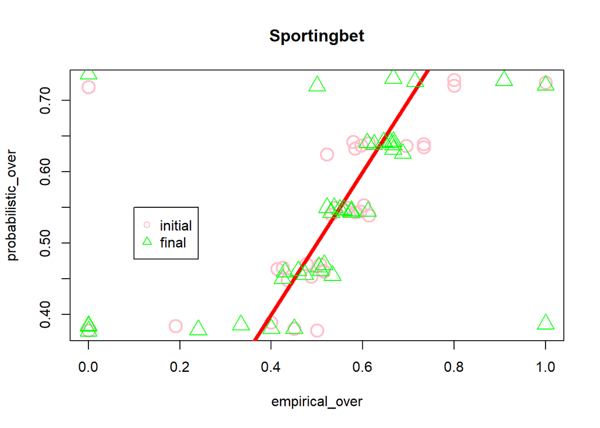

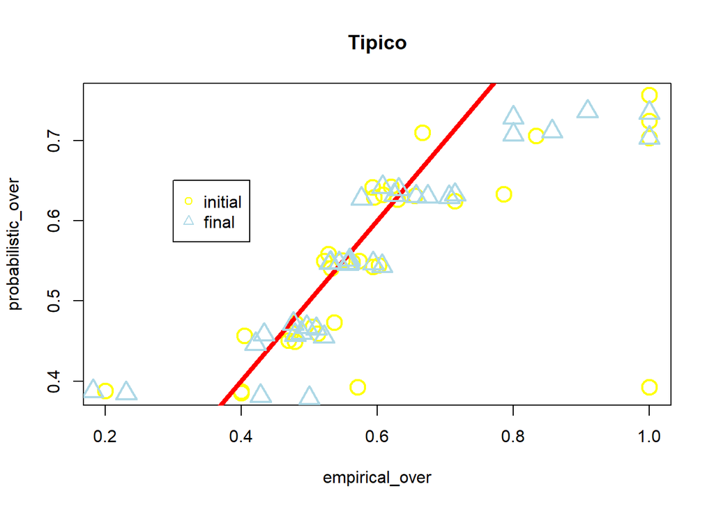

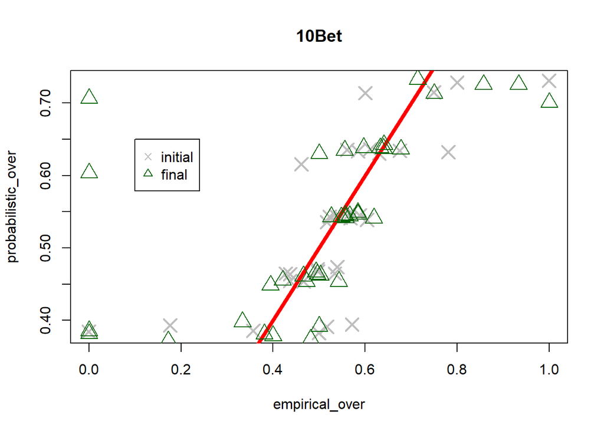

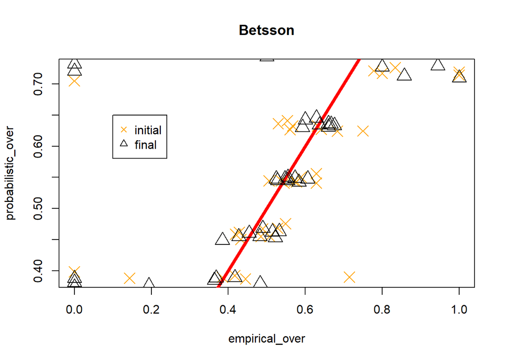

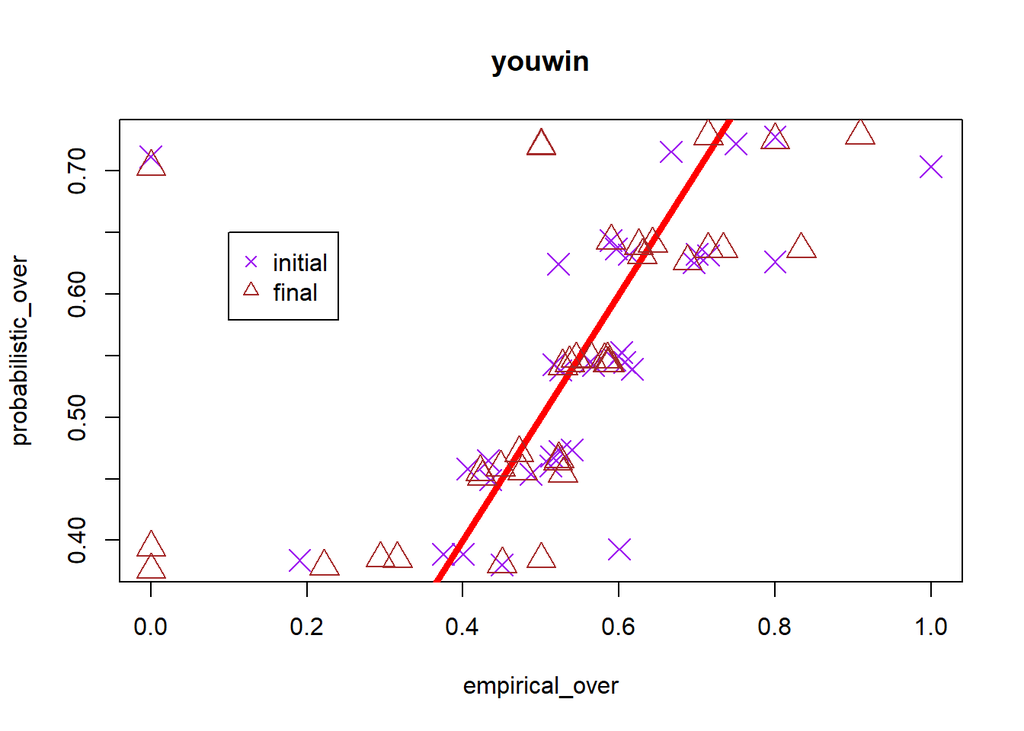

For each case, points are expected to be around x=y line (red lines in plots).

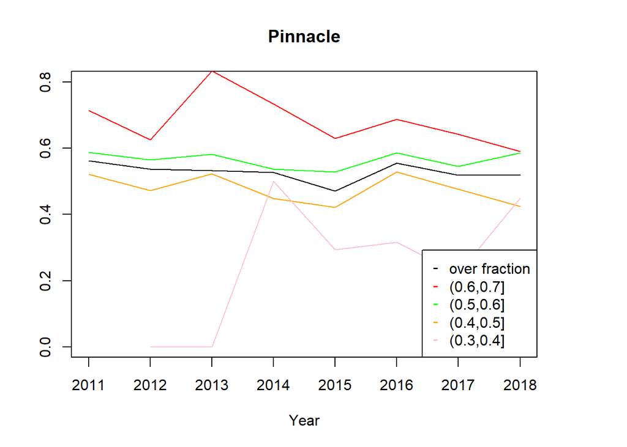

#*Task 2* In this task, we were asked to examine changes in the odds over time by focusing odds for match results. The bookmaker *10Bet* is selected for this task. To understand the change between initial and final odds of the bookmaker a scatter plot is presented.

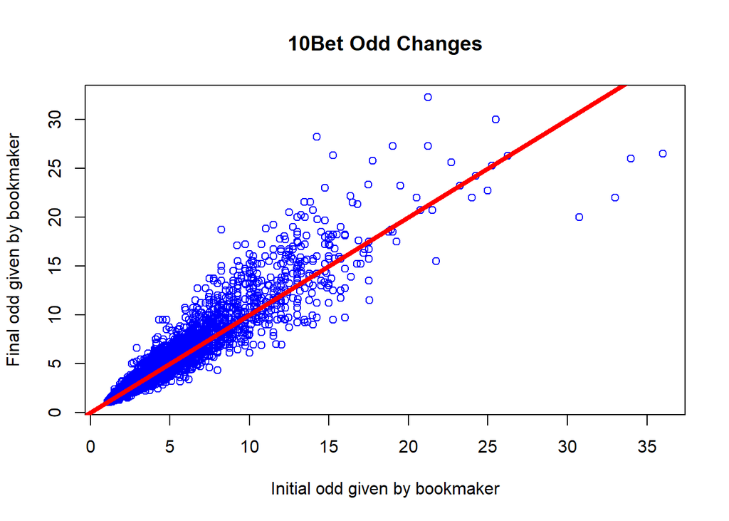

```r
odds_match_result=odd_details[betType=='1x2' & bookmaker == "10Bet"]

odds_match_result[,c("totalhandicap","bookmaker"):=NULL]

change <- odds_match_result[,count_change:=.N,
                            by=list(matchId,oddtype)]

odds_match_result <- odds_match_result[,list(start_odd=odd[1],
                        final_odd=odd[.N]),
                        by=list(matchId,oddtype)]

odds_match_result <- odds_match_result[,difference := (final_odd-start_odd)]
odds_match_result <- odds_match_result[,difference_percentage := difference/start_odd*100]

plot(odds_match_result[,list(start_odd,final_odd)],
     col="blue",
     main="10Bet Odd Changes",
     xlab="Initial odd given by bookmaker",
     ylab="Final odd given by bookmaker")
abline(0,1,col='red', lwd = 4)
```

It can be easily observed that options(1,x,2) with smaller odds remain more stable. Also, the histogram of the percentage changes from initial to final odds can be seen below.

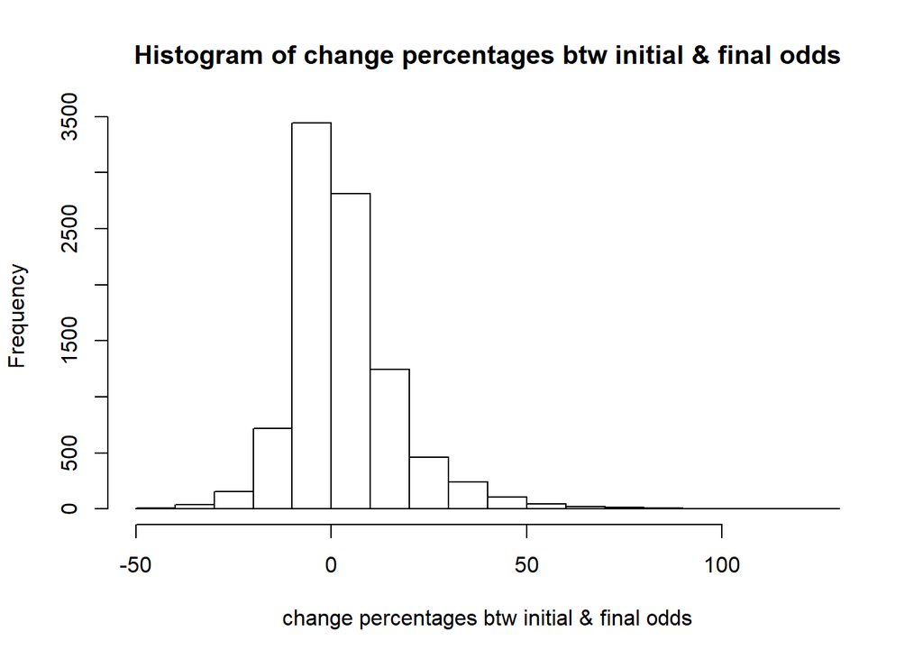

```r
aa <- hist(odds_match_result$difference_percentage,
           main = "Histogram of change percentages btw initial & final odds",
           xlab = "change percentages btw initial & final odds")
```

The changes in odds result in as a strategy of the bookmakers to make more money or sometimes it is because of an important situation which will effect the result of the match directly.

APPENDIX A

```r
setwd("C:/Users/gulsa/Desktop/2018-2019 Güz/IE582")
library(data.table)
library(anytime)

odd_details_file_path <- "homeworks/Homework_1/df9b1196-e3cf-4cc7-9159-f236fe738215_odd_details.rds"
matches <- readRDS("homeworks/Homework_1/df9b1196-e3cf-4cc7-9159-f236fe738215_matches.rds", refhook = NULL)
odd_details <- readRDS(odd_details_file_path)
matches <- unique(matches)
matches$date <- anytime(matches$date)
matches[,Year:=year(date)]
matches[,date:=NULL]

#skoru home&away goals olarak ayırmak için
matches[,c("HomeGoals","AwayGoals"):= tstrsplit(score,':')]

#homegoals ve awaygoals chr olduğu için önce numeric hale getireceğiz
matches$HomeGoals <- as.numeric(matches$HomeGoals)
matches[,AwayGoals:=as.numeric(AwayGoals)]

matches[,TotalGoals:=HomeGoals + AwayGoals]

matches[,IsOver:=0]
matches[TotalGoals>2,IsOver:=1]

odds_ou=odd_details[betType=='ou' & totalhandicap=='2.5']

#remove total handicap; it's useless
odds_ou[,totalhandicap:=NULL]

#order data in ascending order
odds_ou=odds_ou[order(matchId,oddtype,bookmaker,date)]

odds_ou_initial=odds_ou[,list(start_odd=odd[1]),
                          by=list(matchId,oddtype,bookmaker)]

odds_ou_final=odds_ou[,list(final_odd=odd[.N]),
                          by=list(matchId,oddtype,bookmaker)]
```

APPENDIX B

```r
youwin_initial <- odds_ou_initial[bookmaker=='youwin']
youwin_final <- odds_ou_final[bookmaker=='youwin']
youwin_initial[,bookmaker:=NULL]
youwin_final[,bookmaker:=NULL]

youwin_wide_in <- dcast(youwin_initial,
                          matchId~oddtype,
                          value.var = 'start_odd')

youwin_wide_fin <- dcast(youwin_final,
                           matchId~oddtype,
                           value.var = 'final_odd')

#join odds with matches
merged_matches_in=merge(matches,youwin_wide_in,by='matchId')
merged_matches_fin=merge(matches,youwin_wide_fin,by='matchId')

merged_matches_in[,probOver:=1/over]
merged_matches_in[,probUnder:=1/under]

merged_matches_fin[,probOver:=1/over]
merged_matches_fin[,probUnder:=1/under]

merged_matches_in[,totalProb:=probOver+probUnder]
merged_matches_fin[,totalProb:=probOver+probUnder]


merged_matches_in[,probOver:=probOver/totalProb]
merged_matches_in[,probUnder:=probUnder/totalProb]


merged_matches_fin[,probOver:=probOver/totalProb]
merged_matches_fin[,probUnder:=probUnder/totalProb]

merged_matches_in=merged_matches_in[complete.cases(merged_matches_in)]
merged_matches_fin=merged_matches_fin[complete.cases(merged_matches_fin)]

merged_matches_in[,totalProb:=NULL]
merged_matches_fin[,totalProb:=NULL]

cutpoints=seq(0,1,0.1)
merged_matches_in[,odd_cut_over:=cut(probOver,cutpoints)]
merged_matches_fin[,odd_cut_over:=cut(probOver,cutpoints)]

summary_table_in=merged_matches_in[,list(empirical_over=mean(IsOver),
                                         probabilistic_over=mean(probOver),.N),
                                   by=list(Year,odd_cut_over)]

summary_table_fin=merged_matches_fin[,list(empirical_over=mean(IsOver),
                                           probabilistic_over=mean(probOver),.N),
                                     by=list(Year,odd_cut_over)]
summary_table_in=summary_table_in[order(Year)]
summary_table_fin=summary_table_fin[order(Year)]

plot(summary_table_in[,list(empirical_over,probabilistic_over)], main = "youwin", pch=4, col= "purple", cex=2)
abline(0,1,col='red', lwd = 4)

legend(0.1, 0.65, legend= c("initial","final"),
       col=c("purple","brown"), pch = c(4,2) )

points(summary_table_fin[,list(empirical_over,probabilistic_over)],pch = 2, col="brown", cex=2)
```

APPENDIX C

```r
part2 <- matches[,list(Ust = sum(IsOver),
                       Toplam_Mac = .N),  by=Year]

part2[,fraction := (Ust/Toplam_Mac)]

d <- summary_table_fin[odd_cut_over=="(0.6,0.7]"]
alti_yedi <- merge(part2,d,by="Year")

e <- summary_table_fin[odd_cut_over=="(0.5,0.6]"]
bes_alti <- merge(part2,e,by="Year")

a <- summary_table_fin[odd_cut_over=="(0.4,0.5]"]
dort_bes <- merge(part2,a,by="Year")

b <- summary_table_fin[odd_cut_over=="(0.3,0.4]"]
uc_dort <- merge(part2,b,by="Year")

par(mar=c(5,4,4,5))
plot(alti_yedi[,list(Year,fraction)],type="l",ylim=c(0,0.8),main="Pinnacle",ylab=NA)
par(new=T)
lines(alti_yedi[,list(Year,empirical_over)],col="red")
lines(bes_alti[,list(Year,empirical_over)],col="green")
lines(dort_bes[,list(Year,empirical_over)],col="orange")
lines(uc_dort[,list(Year,empirical_over)],col="pink")
legend("bottomright",
       c("over fraction","(0.6,0.7]","(0.5,0.6]","(0.4,0.5]","(0.3,0.4]"),
       col=c("black","red","green","orange","pink"),
       pch = "-")
```